# Sentiment Analysis of Spotify, Amazon Music and Pandora user reviews

The datasets include almost 40,000 user reviews on Spotify, Amazon Music and Pandora collected from Trustpilot. Sentiment analysis is conducted to get an overview of users’ opinion on the three products and compare sentiment for each app in terms of subscription fee, UX/UI, music catalog and app integration with smart devices.

```r
library(tidytext)
library(dplyr)
library(ggplot2)
library(stringr)
library(tidyr)
library(igraph)
library(ggraph)
library(tm)
```

Load the data

```r
print("Spotify")
```

```
## [1] "Spotify"
```

```r
str(spotify)
```

```
## 'data.frame':    7440 obs. of  3 variables:
##  $ ID    : int  1 2 3 4 5 6 7 8 9 10 ...
##  $ Date  : chr  "07-Oct-17" "04-Apr-17" "31-Jul-16" "07-Mar-17" ...
##  $ Review: chr  "Spotify is way, way, way, way, way, way better music app than Pandora. It doesn't limit you on the musicians yo"| __truncated__ "I love, love, love spotify !!!!! I'm 71 years and no very computer literate, if I can learn Spotify anyone can."| __truncated__ "I love this app. I put…
```

```r
print("Amazon")
```

```
## [1] "Amazon"
```

```r
str(amazon)
```

```
## 'data.frame':    12070 obs. of  3 variables:
##  $ ID    : int  1 2 3 4 5 6 7 8 9 10 ...
##  $ Date  : chr  "28-Mar-16" "30-Jul-17" "23-May-17" "04-May-17" ...
##  $ Review: chr  "love this music app. great selection. Better than Pandora. Use it on my Samsung Phone. Not happy, however, that"| __truncated__ "Terrific app." "Nice selection, I have it on a couple of devices, only problem is they're not synced together through amazon music." "It great piece to…
```

```r
print("Pandora")
```

```
## [1] "Pandora"
```

```r
str(pandora)
```

```
## 'data.frame':    19780 obs. of  3 variables:
##  $ ï..ID : int  1 2 3 4 5 6 7 8 9 10 ...
##  $ Date  : chr  "11-Nov-17" "11-Dec-16" "12-Apr-16" "17-Nov-12" ...
##  $ Review: chr  "Love getting my music on all devices." "Love Pandora!! Can listen to my music on any device and in even in my car or on TV with DirectTV!" "i love the app and listen to Pandora often. Is there a voice command in my phone that would make changing stati"| __truncated__ "The pp just…
```

```r
colnames(pandora)[1] <- "ID"
```

## Data prep

```r
#Tokenize sentences
tidy_spotify <- spotify %>% unnest_tokens(word, Review)
tidy_amazon <- amazon %>% unnest_tokens(word, Review)
tidy_pandora <- pandora %>% unnest_tokens(word, Review)
stop_words <- stopwords("en")

cleaner <- function(x){
  filter(x, !word %in% stop_words)
}

tidy_spotify <- cleaner(tidy_spotify)
tidy_amazon <- cleaner(tidy_amazon)
tidy_pandora <- cleaner(tidy_pandora)
```

## Sentiment analysis

Use 3 popular lexicons nrc, bing and afinn to assign numerical values to each word. The sum of scores given to all words (excluding stop words) in a review is used to classify whether a review is positive, neutral or negative.

```r
#Get lexicons
get_sentiments(lexicon="nrc")
```

| word | sentiment |
| --- | --- |
| abacus | trust |
| abandon | fear |
| abandon | negative |
| abandon | sadness |
| abandoned | anger |
| abandoned | fear |
| abandoned | negative |
| abandoned | sadness |
| abandonment | anger |
| abandonment | fear |

[output cut: 9990 more lines]

```r
get_sentiments(lexicon="bing")
```

| word | sentiment |
| --- | --- |
| 2-faced | negative |
| 2-faces | negative |
| a+ | positive |
| abnormal | negative |
| abolish | negative |
| abominable | negative |
| abominably | negative |
| abominate | negative |
| abomination | negative |
| abort | negative |

[output cut: 6778 more lines]

```r
get_sentiments(lexicon="afinn")
```

| word | score |
| --- | --- |
| abandon | -2 |
| abandoned | -2 |
| abandons | -2 |
| abducted | -2 |
| abduction | -2 |
| abductions | -2 |
| abhor | -3 |
| abhorred | -3 |
| abhorrent | -3 |
| abhors | -3 |

[output cut: 2466 more lines]

```r
#Join the lexicons
nrc_join <- function(x){
  x %>% inner_join(get_sentiments("nrc"), by = "word")
}

bing_join <- function(x){
  x %>% inner_join(get_sentiments("bing"), by = "word")
}

afinn_join <- function(x){
  x %>% inner_join(get_sentiments("afinn"), by = "word")
}

nrc_sentiment_spotify <- nrc_join(tidy_spotify)
nrc_sentiment_amazon <- nrc_join(tidy_amazon)
nrc_sentiment_pandora <- nrc_join(tidy_pandora)

bing_sentiment_spotify <- bing_join(tidy_spotify)
bing_sentiment_amazon <- bing_join(tidy_amazon)
bing_sentiment_pandora <- bing_join(tidy_pandora)

afinn_sentiment_spotify <- afinn_join(tidy_spotify)
afinn_sentiment_amazon <- afinn_join(tidy_amazon)
afinn_sentiment_pandora <- afinn_join(tidy_pandora)
```

Select only words with positive and negative sentiment from the nrc_sentiment dataframes and remove those with anger, anticipation, joy, etc. sentiment by subsetting:

```r
#Aggregate review-level popularity information
#Subsetting function
subset_pn <- function(x){
  x[x$sentiment %in% c("positive", "negative"),]
}
nrc_sentiment_spotify <- subset_pn(nrc_sentiment_spotify)
nrc_sentiment_amazon <- subset_pn(nrc_sentiment_amazon)
nrc_sentiment_pandora <- subset_pn(nrc_sentiment_pandora)
```

```r
#Aggregate review-level popularity information
nrc_aggregate <- function(x){
  x %>% select(ID, score) %>%
    group_by(ID) %>%
    summarise(nrc_score=sum(score))
}
bing_aggregate <- function(x){
  x %>% select(ID, score) %>%
    group_by(ID) %>%
    summarise(bing_score=sum(score))
}
afinn_aggregate <- function(x){
  x %>% select(ID, score) %>%
    group_by(ID) %>%
    summarise(afinn_score=sum(score))
}
```

Apply:

```r
#Spotify
nrc_sentiment_spotify <- mutate(nrc_sentiment_spotify, score = ifelse(sentiment == "negative", -1, 1))
nrc_aggregate_spotify <- nrc_aggregate(nrc_sentiment_spotify)
bing_sentiment_spotify <- mutate(bing_sentiment_spotify, score = ifelse(sentiment == "negative", -1, 1))
bing_aggregate_spotify <- bing_aggregate(bing_sentiment_spotify)
afinn_aggregate_spotify <- afinn_aggregate(afinn_sentiment_spotify)
#Amazon
nrc_sentiment_amazon <- mutate(nrc_sentiment_amazon, score = ifelse(sentiment == "negative", -1, 1))
nrc_aggregate_amazon <- nrc_aggregate(nrc_sentiment_amazon)
bing_sentiment_amazon <- mutate(bing_sentiment_amazon, score = ifelse(sentiment == "negative", -1, 1))
bing_aggregate_amazon <- bing_aggregate(bing_sentiment_amazon)
afinn_aggregate_amazon <- afinn_aggregate(afinn_sentiment_amazon)
#Pandora
nrc_sentiment_pandora <- mutate(nrc_sentiment_pandora, score = ifelse(sentiment == "negative", -1, 1))
nrc_aggregate_pandora <- nrc_aggregate(nrc_sentiment_pandora)
bing_sentiment_pandora <- mutate(bing_sentiment_pandora, score = ifelse(sentiment == "negative", -1, 1))
bing_aggregate_pandora <- bing_aggregate(bing_sentiment_pandora)
afinn_aggregate_pandora <- afinn_aggregate(afinn_sentiment_pandora)
```

```r
#Aggregate sentiment info to the original dataset
spotify_sent <- merge(x = spotify, y = nrc_aggregate_spotify, all.x = TRUE, by = "ID")
spotify_sent <- merge(x = spotify_sent, y = bing_aggregate_spotify, all.x = TRUE, by = "ID")
spotify_sent <- merge(x = spotify_sent, y = afinn_aggregate_spotify, all.x = TRUE, by = "ID")
spotify_sent[is.na(spotify_sent)] <- 0

amazon_sent <- merge(x = amazon, y = nrc_aggregate_amazon, all.x = TRUE, by = "ID")
amazon_sent <- merge(x = amazon_sent, y = bing_aggregate_amazon, all.x = TRUE, by = "ID")
amazon_sent <- merge(x = amazon_sent, y = afinn_aggregate_amazon, all.x = TRUE, by = "ID")
amazon_sent[is.na(amazon_sent)] <- 0

pandora_sent <- merge(x = pandora, y = nrc_aggregate_pandora, all.x = TRUE, by = "ID")
pandora_sent <- merge(x = pandora_sent, y = bing_aggregate_pandora, all.x = TRUE, by = "ID")
pandora_sent <- merge(x = pandora_sent, y = afinn_aggregate_pandora, all.x = TRUE, by = "ID")
pandora_sent[is.na(pandora_sent)] <- 0
```

Denote review sentiment:

```r
#Denote review sentiment
##Spotify
  spotify_sent$afinn_judgement <- ifelse(spotify_sent$afinn_score < 0, "negative",
                                      ifelse(spotify_sent$afinn_score > 0, "positive", "neutral"))
  spotify_sent$bing_judgement <- ifelse(spotify_sent$bing_score < 0, "negative",
                                     ifelse(spotify_sent$bing_score > 0, "positive", "neutral"))
  spotify_sent$nrc_judgement <- ifelse(spotify_sent$nrc_score < 0, "negative",
                                    ifelse(spotify_sent$nrc_score > 0, "positive", "neutral"))
  rowSums(table(spotify_sent$bing_judgement, spotify_sent$bing_score))
```

```
## negative  neutral positive
##      431     1178     5831
```

```r
##Amazon
  amazon_sent$afinn_judgement <- ifelse(amazon_sent$afinn_score < 0, "negative",
                                         ifelse(amazon_sent$afinn_score > 0, "positive", "neutral"))
  amazon_sent$bing_judgement <- ifelse(amazon_sent$bing_score < 0, "negative",
                                        ifelse(amazon_sent$bing_score > 0, "positive", "neutral"))
  amazon_sent$nrc_judgement <- ifelse(amazon_sent$nrc_score < 0, "negative",
                                       ifelse(amazon_sent$nrc_score > 0, "positive", "neutral"))
  rowSums(table(amazon_sent$bing_judgement, amazon_sent$bing_score))
```

```
## negative  neutral positive
##     1038     1889     9143
```

```r
##Pandora
  pandora_sent$afinn_judgement <- ifelse(pandora_sent$afinn_score < 0, "negative",
                                         ifelse(pandora_sent$afinn_score > 0, "positive", "neutral"))
  pandora_sent$bing_judgement <- ifelse(pandora_sent$bing_score < 0, "negative",
                                        ifelse(pandora_sent$bing_score > 0, "positive", "neutral"))
  pandora_sent$nrc_judgement <- ifelse(pandora_sent$nrc_score < 0, "negative",
                                       ifelse(pandora_sent$nrc_score > 0, "positive", "neutral"))
  rowSums(table(pandora_sent$bing_judgement, pandora_sent$bing_score))
```

```
## negative  neutral positive
##      964     2676    16140
```

## Sentiment contribution

Which words contribute the most positive/negative sentiment towards the three apps?

Spotify:

```r
bing_wc <- function(x){
  x %>%
    inner_join(get_sentiments("bing"), by = "word") %>%
    count(word, sentiment, sort = TRUE) %>%
    ungroup() %>%
    group_by(sentiment) %>%
    top_n(10) %>%
    ungroup() %>%
    mutate(word = reorder(word, n)) %>%
    ggplot(aes(word, n, fill = sentiment)) +
     geom_col(show.legend = FALSE) +
     facet_wrap(~sentiment, scales = "free_y") +
     labs(y = "Contribution to sentiment",
     x = NULL) +
     coord_flip()
}
```

See which words contribute the most to positive/negative sentiment on Spotify:

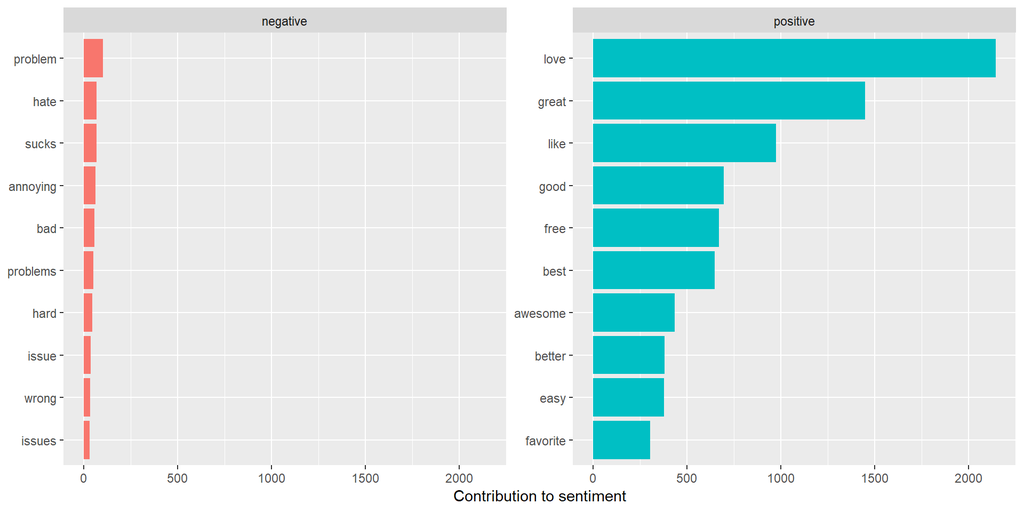

```r
bing_wc(tidy_spotify)
```

Amazon:

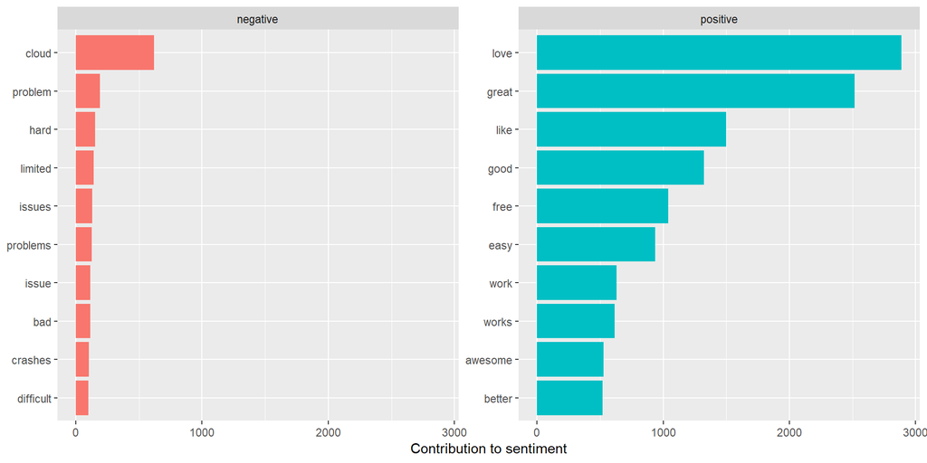

```r
bing_wc(tidy_amazon)
```

And Pandora:

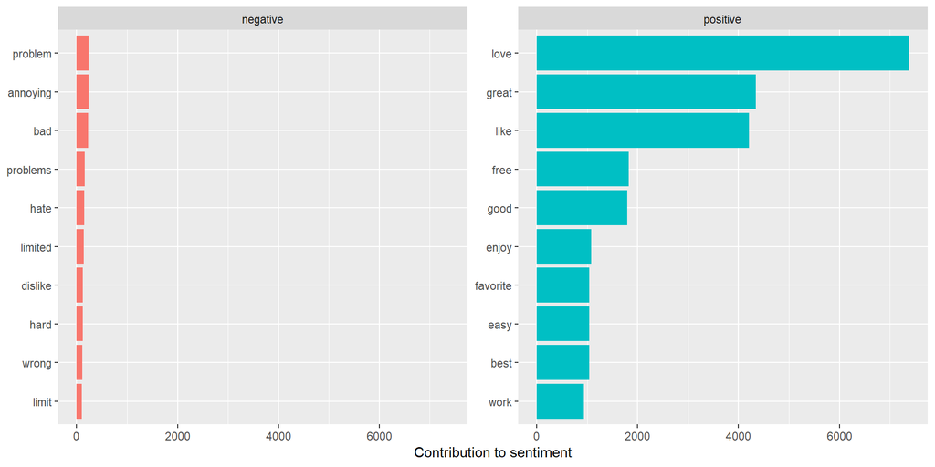

```r
bing_wc(tidy_pandora)
```

## Word cloud

Word cloud of the most common words in each app’s review, with word size indicating frequency level:

```r
library(wordcloud)
c_wordcloud <- function(i){
  i %>%
  count(word) %>%
  with(wordcloud(word, n, max.words = 150, rot.per=0.1, scale = c(6,1), colors=brewer.pal(8, "Dark2")))
}
```

Spotify’s word cloud:

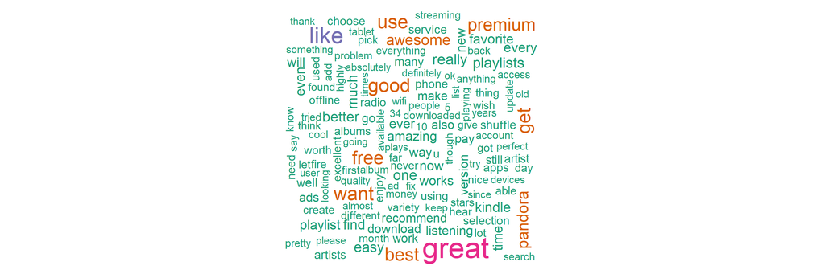

```r
c_wordcloud(tidy_spotify)
```

Amazon’s word cloud:

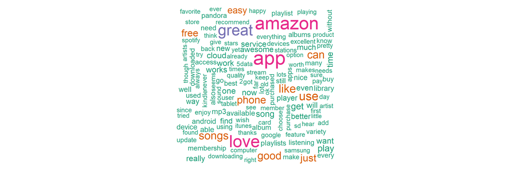

```r
c_wordcloud(tidy_amazon)
```

Pandora’s word cloud:

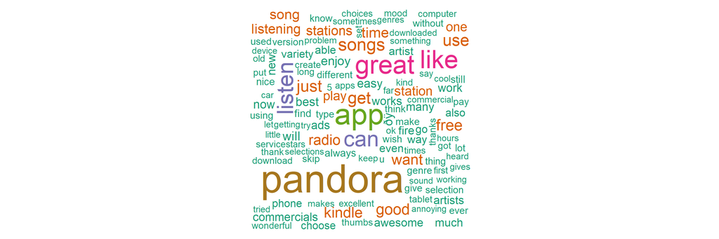

```r
c_wordcloud(tidy_pandora)
```

## Check review sentiment on specific topics

#### Price

How many percent of the reviews on price/subscription fee of each app are positive?

```r
#Check price sentiment
spotifyPrice <- grepl("cost| subscription| price| fee| premium| worth| money| pay| paid| pricing", spotify_sent$Review, ignore.case = TRUE)
sdf <- data.frame(sentiment = spotify_sent$bing_judgement, related_words = spotifyPrice)
sp = sum(sdf$related_words == "TRUE" & sdf$sentiment == "positive")/sum(sdf$related_words == "TRUE")*100
cat("Spotify price =", sp,"%")
```

```
## Spotify price = 75.9009 %
```

```r
amazonPrice <- grepl("cost| subscription| price| fee| premium| worth| money| pay| paid| pricing", amazon_sent$Review, ignore.case = TRUE)
adf <- data.frame(sentiment = amazon_sent$bing_judgement, related_words = amazonPrice)
ap = sum(adf$related_words == "TRUE" & adf$sentiment == "positive")/sum(adf$related_words == "TRUE")*100
cat("Amazon price =", ap,"%")
```

```
## Amazon price = 69.80088 %
```

```r
pandoraPrice <- grepl("cost| subscription| price| fee| premium| worth| money| pay| paid| pricing", pandora_sent$Review, ignore.case = TRUE)
pdf <- data.frame(sentiment = pandora_sent$bing_judgement, related_words = pandoraPrice)
pp = sum(pdf$related_words == "TRUE" & pdf$sentiment == "positive")/sum(pdf$related_words == "TRUE")*100
cat("Pandora price =", pp,"%")
```

```
## Pandora price = 79.85866 %
```

#### UX/UI

```r
#Check UX/UI sentiment
spotifyUX <- grepl("functionality|UI|UX|experience|user experience|user interface|interface|usability|utility|app|glitch|device", spotify_sent$Review, ignore.case = TRUE)
sux <- data.frame(sentiment = spotify_sent$bing_judgement, related_words = spotifyUX)
su <- sum(sdf$related_words == "TRUE" & sdf$sentiment == "positive")/sum(sdf$related_words == "TRUE")*100
cat("Spotify UX =", su,"%")
```

[output not shown]

```r
amazonUX <- grepl("functionaliyu|UI|UX|experience|user experience|user interface|interface|usability|utility|app|glitch|device", amazon_sent$Review, ignore.case = TRUE)
aux <- data.frame(sentiment = amazon_sent$bing_judgement, related_words = amazonUX)
au <- sum(aux$related_words == "TRUE" & aux$sentiment == "positive")/sum(aux$related_words == "TRUE")*100
cat("Amazon UX =", au,"%")
```

```
## Amazon UX = 70.12021 %
```

```r
pandoraUX <- grepl("functionality|UI|UX|experience|user experience|user interface|interface|usability|utility|app|glitch|device", pandora_sent$Review, ignore.case = TRUE)
pux <- data.frame(sentiment = pandora_sent$bing_judgement, related_words = pandoraUX)
pu <- sum(pux$related_words == "TRUE" & pux$sentiment == "positive")/sum(pux$related_words == "TRUE")*100
cat("Pandora UX", pu,"%")
```

```
## Pandora UX 82.72777 %
```

#### Music catalog

```r
#Check music catalog
##Spotify
spotifyMusic <- grepl("music selection| selection| music| customized| playlist| recommendation| AI| discovery| variety| song| songs| library| broad| wide| range| catalogue| list| singers", spotify_sent$Review, ignore.case = TRUE)
sm <- data.frame(sentiment = spotify_sent$bing_judgement, related_words = spotifyMusic)
smc <- sum(sm$related_words == "TRUE" & sm$sentiment == "positive")/sum(sm$related_words == "TRUE")*100
cat("Spotify catalog =", smc,"%")
```

```
## Spotify catalog = 83.78454 %
```

```r
##Amzon
amazonMusic <- grepl("music selection| selection| music| customized| playlist| recommendation| AI| discovery| variety| song| songs| library| broad| wide| range| catalogue| list| singers", amazon_sent$Review, ignore.case = TRUE)
amusic <- data.frame(sentiment = amazon_sent$bing_judgement, related_words = amazonMusic)
amc <- sum(amusic$related_words == "TRUE" & amusic$sentiment == "positive")/sum(amusic$related_words == "TRUE")*100
cat("Amazon catalog =", amc,"%")
```

```
## Amazon catalog = 76.60958 %
```

```r
##Pandora
pandoraMusic <- pandoraMusic <- grepl("music selection| selection| music| customized| playlist| recommendation| AI| discovery| variety| song| songs| library| broad| wide| range| catalogue| list| singers", pandora_sent$Review, ignore.case = TRUE)
pmusic <- data.frame(sentiment = pandora_sent$bing_judgement, related_words = pandoraMusic)
pmc <- sum(pmusic$related_words == "TRUE" & pmusic$sentiment == "positive")/sum(pmusic$related_words == "TRUE")*100
cat("Pandora catalog =", pmc,"%")
```

```
## Pandora catalog = 86.57468 %
```

#### App’s integration with smart devices

```r
#Check integration
spotifyIn <- grepl("device| connection| connect| speaker| smart speaker| alexa| google home| siri| echo| integrate| integration| seamless| across| sync| synchronize| synchronization| bluetooth| strong| car| headphone| earphone| phone| airpod", spotify_sent$Review, ignore.case = TRUE)
si <- data.frame(sentiment = spotify_sent$bing_judgement, related_words = spotifyIn)
s <- sum(si$related_words == "TRUE" & si$sentiment == "positive")/sum(si$related_words == "TRUE")*100
cat("Spotify integration =", s,"%")
```

```
## Spotify integration = 74.68619 %
```

```r
amazonIn <- grepl("device| connection| connect| speaker| smart speaker| alexa| google home| siri| echo| integrate| integration| seamless| across| sync| synchronize| synchronization| bluetooth| strong| car| headphone| earphone| phone| airpod", amazon_sent$Review, ignore.case = TRUE)
ai <- data.frame(sentiment = amazon_sent$bing_judgement, related_words = amazonIn)
a <- sum(ai$related_words == "TRUE" & ai$sentiment == "positive")/sum(ai$related_words == "TRUE")*100
cat("Amazon integration =", a,"%")
```

```
## Amazon integration = 66.28849 %
```

```r
pandoraIn <- grepl("device| connection| connect| speaker| smart speaker| alexa| google home| siri| echo| integrate| integration| seamless| across| sync| synchronize| synchronization| bluetooth| strong| car| headphone| earphone| phone| airpod", pandora_sent$Review, ignore.case = TRUE)
pi <- data.frame(sentiment = pandora_sent$bing_judgement, related_words = pandoraIn)
p <- sum(pi$related_words == "TRUE" & pi$sentiment == "positive")/sum(pi$related_words == "TRUE")*100
cat("Pandora integration =", p, "%")
```

```
## Pandora integration = 81.35304 %
```

## N-gram visualization

N-gram is a useful technique to see which words often go together in the document, so that we can make more sense of the text’s content. Here we will start with bigrams (pairs of words).

```r
#Word clustering using bigrams
bi_graph <- subset(spotify_sent, bing_judgement == "positive")
app_bigram <- bi_graph %>% unnest_tokens(bigram, Review, token = "ngrams", n = 2)

##Separate
bigrams_separated <- app_bigram %>%
    separate(bigram, c("word1", "word2"), sep = " ")

##Filter
bigrams_filtered <- bigrams_separated %>%
    filter(!word1 %in% stop_words) %>%
    filter(!word2 %in% stop_words)

##New bigram counts:
bigram_counts <- bigrams_filtered %>%
    count(word1, word2, sort = TRUE)

##Unite
bigrams_united <- bigrams_filtered %>%
    unite(bigram, word1, word2, sep = " ")
```

```r
##Filter for only relatively common combinations
bigram_graph <- bigram_counts %>%
    filter(n > 10) %>%
    graph_from_data_frame()
bigram_graph
```

```
## IGRAPH 0928570 DN-- 157 190 --
## + attr: name (v/c), n (e/n)
## + edges from 0928570 (vertex names):
##  [1] music   ->app       NA      ->NA        great   ->app
##  [4] best    ->music     can     ->listen    love    ->spotify
##  [7] great   ->music     good    ->app       free    ->music
## [10] app     ->ever      favorite->music     kindle  ->fire
## [13] favorite->songs     love    ->love      works   ->great
## [16] free    ->version   best    ->app       new     ->music
## [19] awesome ->app       can     ->find      good    ->music
## [22] highly  ->recommend much    ->better    every   ->song
## + ... omitted several edges
```

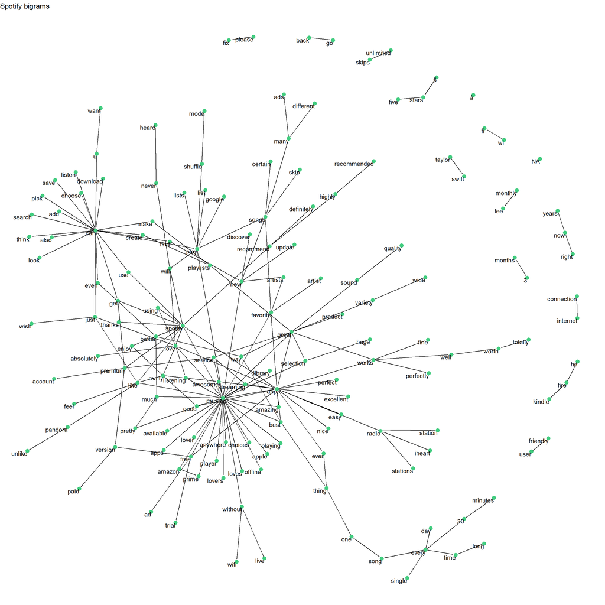

```r
##void-themed graph
  a <- grid::arrow(type = "closed", length = unit(0.15, "inches"))
  ggraph(bigram_graph, layout = "fr") +
  geom_edge_link(show.legend = FALSE,
                   end_cap = circle(.07, 'inches')) +
  geom_node_point(color = "seagreen3", size = 3) +
  geom_node_text(aes(label = name), vjust = 1, hjust = 1) +
  theme_void() +
  labs(title="Spotify bigrams")
```

With Amazon:

```r
#Word clustering using bigrams
library(tidyr)
bi_graph <- subset(amazon_sent, bing_judgement == "positive")
app_bigram <- bi_graph %>% unnest_tokens(bigram, Review, token = "ngrams", n = 2)
app_bigram %>%
  count(bigram, sort = TRUE)
```

| bigram | n |
| --- | --- |
| love it | 1025 |
| i love | 938 |
| on my | 711 |
| NA | 709 |
| i have | 705 |
| this app | 698 |
| easy to | 663 |
| listen to | 622 |
| to use | 618 |
| the music | 607 |

[output cut: 9990 more lines]

```r
##Separate
bigrams_separated <- app_bigram %>%
    separate(bigram, c("word1", "word2"), sep = " ")

##Filter
bigrams_filtered <- bigrams_separated %>%
    filter(!word1 %in% stop_words) %>%
    filter(!word2 %in% stop_words)
##New bigram counts:
bigram_counts <- bigrams_filtered %>%
    count(word1, word2, sort = TRUE)

##Unite
bigrams_united <- bigrams_filtered %>%
    unite(bigram, word1, word2, sep = " ")

##Filter the most common bigrams
bigram_graph <- bigram_counts %>%
    filter(n > 20) %>%
    graph_from_data_frame()
```

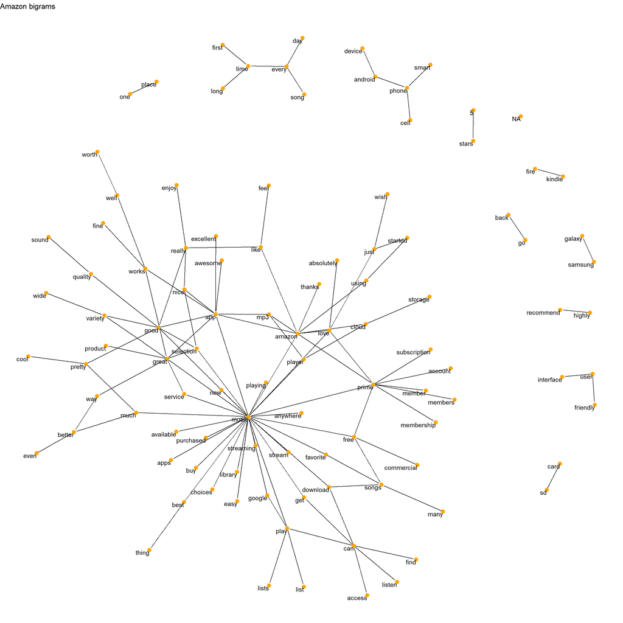

```r
##void-themed graph
a <- grid::arrow(type = "closed", length = unit(0.15, "inches"))
ggraph(bigram_graph, layout = "fr") +
  geom_edge_link(show.legend = FALSE,
                   end_cap = circle(.07, 'inches')) +
  geom_node_point(color = "orange", size = 3) +
  geom_node_text(aes(label = name), vjust = 1, hjust = 1) +
  theme_void() +
  labs(title="Amazon bigrams")
```

And Pandora:

```r
#Word clustering using bigrams
library(tidyr)
bi_graph <- subset(pandora_sent, bing_judgement == "positive")
app_bigram <- bi_graph %>% unnest_tokens(bigram, Review, token = "ngrams", n = 2)
app_bigram %>%
  count(bigram, sort = TRUE)
```

| bigram | n |
| --- | --- |
| i love | 3091 |
| listen to | 2613 |
| love it | 2029 |
| this app | 1738 |
| of music | 1535 |
| on my | 1532 |
| i like | 1385 |
| i have | 1380 |
| to listen | 1363 |
| love pandora | 1324 |

[output cut: 9990 more lines]

```r
##Separate
bigrams_separated <- app_bigram %>%
    separate(bigram, c("word1", "word2"), sep = " ")

##Filter
bigrams_filtered <- bigrams_separated %>%
    filter(!word1 %in% stop_words) %>%
    filter(!word2 %in% stop_words)
##New bigram counts:
bigram_counts <- bigrams_filtered %>%
    count(word1, word2, sort = TRUE)

##Unite
bigrams_united <- bigrams_filtered %>%
    unite(bigram, word1, word2, sep = " ")

##Filter the most common bigrams
bigram_graph <- bigram_counts %>%
    filter(n > 25) %>%
    graph_from_data_frame()
```

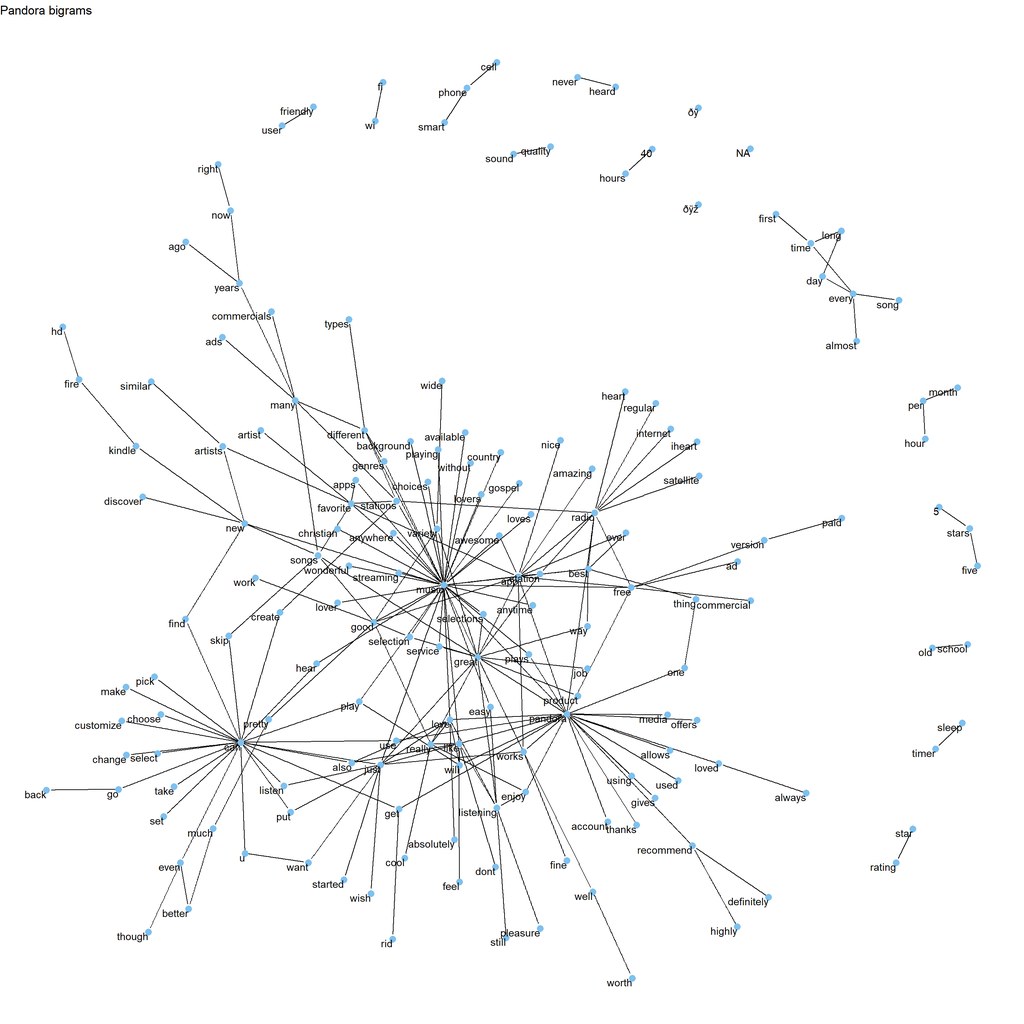

```r
##void-themed graph
a <- grid::arrow(type = "closed", length = unit(0.15, "inches"))
ggraph(bigram_graph, layout = "fr") +
  geom_edge_link(show.legend = FALSE,
                   end_cap = circle(.07, 'inches')) +
  geom_node_point(color = "skyblue2", size = 3) +
  geom_node_text(aes(label = name), vjust = 1, hjust = 1) +
  theme_void() +
  labs(title="Pandora bigrams")
```

The bigram plots above could help us see the links between the most common words, better understand review contexts and explore notable topics for further analysis.